# Change Healthcare IMN Coding Challenge

## Background

There are many problems in programming that involve collections of objects that are very similar but differ in their containing ability. A common case is that of an employee hierarchy. All people in a company are employees, yet some are managers and so, in a sense, contain collections of other employees.

## Problem Statement

For the following office hierarchy, write a test program that does these things:  
●Read the input data (below) from a local file  
●Print out an ASCII employee tree (any format you want)  
●Print out the total salary requirements for the entire company.  
Consider creating objects that would encapsulate the employee and manager properties.

Extra Credit: Sort employees alphabetically  
Mega Extra Credit: Build unit tests for the code  
SuperMega Extra Credit: Utilize language constructs, frameworks, or libraries to represent the data objects and perform automatic data validation on the data models.

Please use copious comments and document fully all your assumptions and reasoning. It’s better to have a clear, documented approach that doesn’t compile than to have something that works but is hacked up and undocumented.

## Sample input (saved as employees.json)

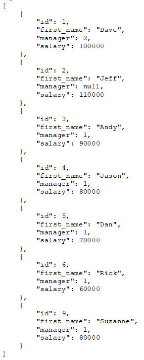

## Sample output

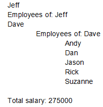

# Ricky's solution here

```python
import json
from treelib import Node, Tree
import jsonpath
import sys
class Employee:
  def __init__(self,id,first_name,manager,salary):
    # according to the input file, each Employee has the following 4 properties
      self.id=id
      self.first_name=first_name
      self.manager=manager
      self.salary=salary

  def to_string(self):
      return {"id":self.id,
              "first_name":self.first_name,
              "manager":self.manager,
              "salary":self.salary}

class Manager(Employee):
    def __init__(self,id,first_name,manager,salary,list_followers):
        super().__init__(id,first_name,manager,salary)
    # manager inherits the properties of employee with one additional property, list of followers
        self.list_followers=list_followers
    def print_manager(self):
        print(self.first_name," has ",len(self.list_followers),"direct followers")

gint_total_salary=0

# -----------------------------------------------------------------------------------------------------------------
# Description: the function generates a dictionary which contains information of all employees
# Input: read json data
# output:
#           {
#              "2":Manager("Jeff")
#              "1":Manager("Dave")
#              "3":Employee("Andy")
#                     :
#           }
#           b1. each item/key in the dictionary represents ID of given employee
#           b1. if a given member has direct followers, then his/her information is encapsulated as Manager object,
#               otherwises are encapsulated as Employee object.
# -----------------------------------------------------------------------------------------------------------------
def genEmployeesDict(data):
    dict_company={}
    int_root_id=0
    for i in range(0,len(data)):
        str_id=str(data[i]['id'])
        list_followers=[]
        if data[i]['manager']==None:
            # find the id of boss/root
            int_root_id=data[i]['id']
        for j in range(0,len(data)):
            # collect followers of given manager
            if data[i]['id']==data[j]['manager']:
                list_followers.append(Employee(data[j]['id'],data[j]['first_name'],data[j]['manager'],data[j]['salary']))
        if len(list_followers)!=0:
            # save property of given manager as an object of Manager
            dict_company[str_id]=Manager(data[i]['id'],data[i]['first_name'],data[i]['manager'],data[i]['salary'],list_followers)
        else:
            # save property of given employee, who has no followers, as an object of Employee
            dict_company[str_id]=Employee(data[i]['id'],data[i]['first_name'],data[i]['manager'],data[i]['salary'])
    return [dict_company,int_root_id]

# -----------------------------------------------------------------------------------------------------------------
# Description: The function recursively disaply tree type by the given dictionary instance
# Input:
#   a.bool_sort: The flag determines the result (tree) is sorted or unsorted
#   b.str_space: The space size
#   c.dict_company: the output generated by function genEmployeesDict
#   d.int_started_id: the starting point (id of employee) for recursive display
# output:
#   the tree structure displays in the console
# -----------------------------------------------------------------------------------------------------------------
def showTree(bool_sort,str_space,dict_company,int_started_id):
    print(str_space,dict_company[str(int_started_id)].first_name)
    list_followers=[]
    if isinstance(dict_company[str(int_started_id)],Manager)==True:
        list_followers=dict_company[str(int_started_id)].list_followers
    salary=dict_company[str(int_started_id)].salary
    global gint_total_salary
    gint_total_salary+=salary
    # if the given member has followers, recursively display the followers
    if len(list_followers)!=0:
        print(str_space,"Employees of:",dict_company[str(int_started_id)].first_name)
        str_space+="         "
    if bool_sort==True:
        list_followers.sort(key=lambda x:x.first_name)
    for i in range(0,len(list_followers)):
        started_id=str(list_followers[i].id)
        # recursively display the tree
        showTree(bool_sort,str_space,dict_company,started_id)

# -----------------------------------------------------------------------------------------------------------------
# Description: the function recursively disaply tree type by the given dictionary instance and treelib
# Input:
#   a.tree: the tree node of treelib
#   b.bool_sort: The flag determines the result (tree) is sorted or unsorted
#   c.str_space: The space size
#   d.dict_company: the output generated by function genEmployeesDict
#   e.int_started_id: the starting point (id of employee) for recursive display
# output:
#   the tree structure of treelib displays in the console
# -----------------------------------------------------------------------------------------------------------------
def showByTreelib(tree, bool_sort,str_space,dict_company,int_started_id):
    list_followers=[]
    if isinstance(dict_company[str(int_started_id)],Manager)==True:
        list_followers=dict_company[str(int_started_id)].list_followers
    if len(list_followers)!=0:
        str_parent_name=dict_company[str(int_started_id)].first_name
        str_space+="         "
    if bool_sort==True:
        list_followers.sort(key=lambda x:x.first_name)
    for i in range(0,len(list_followers)):
        started_id=str(list_followers[i].id)
        str_child_name=str(list_followers[i].first_name)
        # recursively build the tree of Treelib
        tree.create_node(str_child_name,str_child_name,str_parent_name)
        showByTreelib(tree,bool_sort,str_space,dict_company,started_id)

# -----------------------------------------------------------------------------------------------------------------
# Description: the function shows how many followers each manager have
# Input: the dictionary generated by function genEmployeesDict
# output: how many followers each manager have
# -----------------------------------------------------------------------------------------------------------------
def showManager(dict_company):
    print(">------------------------------------<")
    print(">        manager information         <")
    print(">------------------------------------<")
    for key in dict_company:
        if isinstance(dict_company[key], Manager)==True:
            dict_company[key].print_manager()
    print("")

# -----------------------------------------------------------------------------------------------------------------
# Description: the function checks the integrity and correctness of input JSON data
# Input: the JSON data read from file
# output: incorrectness found in the data if any
# -----------------------------------------------------------------------------------------------------------------
def checkInputDataIntegrity(data):
    list_error_msg=[]
    # id's integrity/correctness check
    list_id=jsonpath.jsonpath(data, '$..*.id')
    str_error=""
    for i in range(0,len(list_id)):
        if isinstance(list_id[i],int)==False:
            str_error="id is not an integer: obj#"+str(i)
            list_error_msg.append(str_error)
    # check if employees share the same id
    set_id=set(list_id)
    if len(list_id)!=len(set_id):
        list_error_msg.append("employees share the same id")

    # integrity/correctness check for first_name, salary, manager
    for i in range(0,len(data)):
        if isinstance(data[i]["first_name"],str)==False:
            str_error="first_name is not a string: obj#"+str(i)
            list_error_msg.append(str_error)
        if isinstance(data[i]["manager"],int) and data[i]["manager"]<0:
            str_error="manager is a negative number: obj#"+str(i)
            list_error_msg.append(str_error)
        if isinstance(data[i]["salary"],int)==False:
            str_error="salary is not an integer: obj#"+str(i)
            list_error_msg.append(str_error)
        else:
            if data[i]["salary"]<0:
                str_error="salary is a negative number: obj#"+str(i)
                list_error_msg.append(str_error)
    return list_error_msg

def main(file_name):
    try:
        with open(file_name) as f:
            try:
                data = json.load(f)
            except ValueError:
                print('Decoding JSON has failed. Please check if input file has correct JSON format')
                sys.exit()
    except OSError:
        print("Could not open/read file",file_name," Please double check the file name")
        sys.exit()

    list_error_msg=checkInputDataIntegrity(data)
    if len(list_error_msg)!=0:
        print("Data integrity/correctness check failed because of:")
        for i in range(0,len(list_error_msg)):
            print(i+1,":",list_error_msg[i])
        sys.exit()
    int_data_salary=0
    for i in range(0,len(data)):
        int_data_salary+=data[i]['salary']
    dict_company,int_root_id=genEmployeesDict(data)
    space=""
    global gint_total_salary
    gint_total_salary=0
    # Print unsorted tree structure

    print("**************************************")
    print("*        unsorted tree type          *")
    print("**************************************")
    showTree(False,space,dict_company,int_root_id)
    print("Total salary:",gint_total_salary)
    print("")

    print("**************************************")
    print("*        sorted tree type            *")
    print("**************************************")
    gint_total_salary=0
    # Print alphabetically sorted tree structure
    showTree(True,space,dict_company,int_root_id)
    print("Total salary:",gint_total_salary)
    print("")

    print("**************************************")
    print("*       sorted tree by treelib       *")
    print("**************************************")
    tree = Tree()
    tree.create_node(dict_company[str(int_root_id)].first_name, dict_company[str(int_root_id)].first_name)  # No parent means its the root node
    showByTreelib(tree,True,space,dict_company,int_root_id)
    tree.show(line_type="ascii-em")
    print("")
    showManager(dict_company)
    return [gint_total_salary,dict_company,int_root_id,int_data_salary]
```

```python
def unit_tests(file_name):
    [gint_total_salary,dict_company,int_root_id,int_data_salary]=main(file_name)
    assert isinstance(int_root_id, int)
    assert int_root_id>=0
    assert isinstance(gint_total_salary, int)
    assert gint_total_salary>0
    #check if the two total salary numbers calucated by two different methods are the same or not
    assert gint_total_salary==int_data_salary
    assert isinstance(dict_company,dict)
    for ele in jsonpath.jsonpath(dict_company, '$..*'):
        # check if all values in company's dictionary are either Manager or Employee object
        assert isinstance(ele, Manager) or isinstance(ele, Employee)
        # check if id of each object is an integer, not None, and not 0
        assert ele.id!=None and ele.id!=0 and isinstance(ele.id,int)
        # check if first_name of each object is a string, not None, and not ""
        assert ele.first_name!=None and ele.first_name!="" and isinstance(ele.first_name,str)
        # check if salary of each object is an integer, not None, and not 0
        assert ele.salary!=None and ele.salary!=0 and isinstance(ele.salary,int)
        if ele.manager!=None:
            # check if manager of each object is integer, and not 0
            assert ele.manager!=0 and isinstance(ele.manager,int)
        if isinstance(ele, Manager):
            # if the object is a Manager, check if list_followers is a list, not None, and length of list is not 0
            assert ele.list_followers!=None and isinstance(ele.list_followers, list) and len(ele.list_followers)!=0
```

```python
print(">>>>>>>>>>>>>>>>>>>>>>>>>>>>>>>>>>>>>>>>>>>>>>>")
print(">       test with employee1.json started      >")
print(">>>>>>>>>>>>>>>>>>>>>>>>>>>>>>>>>>>>>>>>>>>>>>>")
unit_tests('employee1.json')
```

```
>>>>>>>>>>>>>>>>>>>>>>>>>>>>>>>>>>>>>>>>>>>>>>>
>       test with employee1.json started      >
>>>>>>>>>>>>>>>>>>>>>>>>>>>>>>>>>>>>>>>>>>>>>>>
*        unsorted tree type          *
 Jeff
 Employees of: Jeff
          Dave
          Employees of: Dave
                   Andy
                   Jason
                   Dan
                   Rick
                   Suzanne
Total salary: 590000

*        sorted tree type            *
 Jeff
 Employees of: Jeff
          Dave
          Employees of: Dave
                   Andy
                   Dan
                   Jason
                   Rick
                   Suzanne
Total salary: 590000

*       sorted tree by treelib       *
Jeff
╚══ Dave
    ╠══ Andy
    ╠══ Dan
    ╠══ Jason
    ╠══ Rick
    ╚══ Suzanne


>------------------------------------<
>        manager information         <
>------------------------------------<
Dave  has  5 direct followers
Jeff  has  1 direct followers
```

```python
print(">>>>>>>>>>>>>>>>>>>>>>>>>>>>>>>>>>>>>>>>>>>>>>>")
print(">       test with employee2.json started      >")
print(">>>>>>>>>>>>>>>>>>>>>>>>>>>>>>>>>>>>>>>>>>>>>>>")
unit_tests('employee2.json')
```

```
>>>>>>>>>>>>>>>>>>>>>>>>>>>>>>>>>>>>>>>>>>>>>>>
>       test with employee2.json started      >
>>>>>>>>>>>>>>>>>>>>>>>>>>>>>>>>>>>>>>>>>>>>>>>
*        unsorted tree type          *
 Jeff
 Employees of: Jeff
          Dave
          Employees of: Dave
                   Andy
                   Jason
                   Dan
                   Employees of: Dan
                            Ricky
                            Employees of: Ricky
                                     Joe
                                     Jess
                   Rick
                   Suzanne
          Lily
          TJ
          Apple
Total salary: 1070000

*        sorted tree type            *
 Jeff
 Employees of: Jeff
          Apple
          Dave
          Employees of: Dave
                   Andy
                   Dan
                   Employees of: Dan
                            Ricky
                            Employees of: Ricky
                                     Jess
                                     Joe
                   Jason
                   Rick
                   Suzanne
          Lily
```

[output cut: 11 more lines]

```
║   ║       ╚══ Joe
║   ╠══ Jason
║   ╠══ Rick
║   ╚══ Suzanne
╠══ Lily
╚══ TJ


>------------------------------------<
>        manager information         <
>------------------------------------<
Dave  has  5 direct followers
Jeff  has  4 direct followers
Dan  has  1 direct followers
Ricky  has  2 direct followers
```

```python
print(">>>>>>>>>>>>>>>>>>>>>>>>>>>>>>>>>>>>>>>>>>>>>>>")
print(">       test with employee3.json started      >")
print(">>>>>>>>>>>>>>>>>>>>>>>>>>>>>>>>>>>>>>>>>>>>>>>")
unit_tests('employee3.json')
```

```
>>>>>>>>>>>>>>>>>>>>>>>>>>>>>>>>>>>>>>>>>>>>>>>
>       test with employee3.json started      >
>>>>>>>>>>>>>>>>>>>>>>>>>>>>>>>>>>>>>>>>>>>>>>>
*        unsorted tree type          *
 Jeff
 Employees of: Jeff
          Dave
          Employees of: Dave
                   Andy
                   Jason
                   Dan
                   Employees of: Dan
                            Ricky
                            Employees of: Ricky
                                     Joe
                                     Jess
                                     Employees of: Jess
                                              Cess_kid1
                                              Aess_kid2
                                              Bess_kid3
                   Rick
                   Suzanne
                   Employees of: Suzanne
                            Suzanne_kid1
                            Luzanne_kid1
                            Buzanne_kid1
          Lily
          Employees of: Lily
                   dily_kid1
                   cily_kid1
                   bily_kid1
          TJ
          Apple
Total salary: 1079000

*        sorted tree type            *
 Jeff
 Employees of: Jeff
          Apple
          Dave
```

[output cut: 47 more lines]

```
║   ╠══ cily_kid1
║   ╚══ dily_kid1
╚══ TJ


>------------------------------------<
>        manager information         <
>------------------------------------<
Dave  has  5 direct followers
Jeff  has  4 direct followers
Dan  has  1 direct followers
Suzanne  has  3 direct followers
Ricky  has  2 direct followers
Lily  has  3 direct followers
Jess  has  3 direct followers
```

```python
print(">>>>>>>>>>>>>>>>>>>>>>>>>>>>>>>>>>>>>>>>>>>>>>>>>>>>>>>>>>>>>>>")
print(">       test with employee4.json (with problems) started      >")
print(">>>>>>>>>>>>>>>>>>>>>>>>>>>>>>>>>>>>>>>>>>>>>>>>>>>>>>>>>>>>>>")
unit_tests('employee4.json')
```

```
>>>>>>>>>>>>>>>>>>>>>>>>>>>>>>>>>>>>>>>>>>>>>>>>>>>>>>>>>>>>>>>
>       test with employee4.json (with problems) started      >
>>>>>>>>>>>>>>>>>>>>>>>>>>>>>>>>>>>>>>>>>>>>>>>>>>>>>>>>>>>>>>
Data integrity/correctness check failed because of:
1 : id is not an integer: obj#2
2 : employees share the same id
3 : first_name is not a string: obj#3
4 : manager is a negative number: obj#3
5 : salary is a negative number: obj#5
```

```
An exception has occurred, use %tb to see the full traceback.

SystemExit
```